# MichaelY-DATA607-Week02-Movies

Michael Y.

September 8, 2019

# Assignment 2: Movies Database

## **Already done (using MySQL Workbench):**

Choose six recent popular movies.

Ask at least five people that you know (friends, family, classmates, imaginary friends) to rate each of these movies that they have seen on a scale of 1 to 5.

Take the results (observations) and store them in a SQL database. (See attached SQL script for database creation and loading.)

## **To be done here:**

Load the information into an R dataframe, and examine it.

##### Load up some libraries

```r
library(RMySQL)
```

```r
library(dplyr)
library(ggplot2)
library(psych)
```

### Connect to the MySql database and retrieve the data:

```r
# I created "stduser" as a read-only account in my database which only has "select" privilege
connstd <- dbConnect(MySQL(), user="stduser", password="password",
                     dbname="Week2_Movies", host="localhost")

# Create a query which joins the 3 database tables,
# replacing the auto-generated ID codes with the movie names and the reviewers' names

query <- 'Select M.Movie_title, F.Friend_name, R.Rating
          From Movies as M, Friends as F, Ratings as R
          Where (M.Movie_id = R.Movie_ID AND F.Friend_id = R.Friend_ID);'

# Execute the query
result <- dbGetQuery(connstd, query)

# Close the database connection
discard <- dbDisconnect(connstd) # this function returns "TRUE", so assignment suppresses printing
```

##### The dimensions of the results dataframe are 30, 3 .

```r
# structure of the results dataframe
str(result)
```

```
## 'data.frame':    30 obs. of  3 variables:
##  $ Movie_title: chr  "Aladdin (2019)" "Aladdin (2019)" "Aladdin (2019)" "Aladdin (2019)" ...
##  $ Friend_name: chr  "Andrew" "Bernard" "Charlie" "Dilbert" ...
##  $ Rating     : int  1 5 1 2 4 4 1 3 2 1 ...
```

```r
# summary of the results dataframe
summary(result)
```

```
##  Movie_title        Friend_name            Rating
##  Length:30          Length:30          Min.   :1.00
##  Class :character   Class :character   1st Qu.:1.00
##  Mode  :character   Mode  :character   Median :2.00
##                                        Mean   :2.52
##                                        3rd Qu.:4.00
##                                        Max.   :5.00
##                                        NA's   :1
```

### List the results (there are only 30 rows):

```r
result
```

```
##                  Movie_title Friend_name Rating
## 1             Aladdin (2019)      Andrew      1
## 2             Aladdin (2019)     Bernard      5
## 3             Aladdin (2019)     Charlie      1
## 4             Aladdin (2019)     Dilbert      2
## 5             Aladdin (2019)     Ernesto      4
## 6          Avengers: Endgame      Andrew      4
## 7          Avengers: Endgame     Bernard      1
## 8          Avengers: Endgame     Charlie      3
## 9          Avengers: Endgame     Dilbert      2
## 10         Avengers: Endgame     Ernesto      1
## 11            Captain Marvel      Andrew      4
## 12            Captain Marvel     Bernard      5
## 13            Captain Marvel     Charlie      5
## 14            Captain Marvel     Dilbert      2
```

[output cut: 16 more lines]

##### Describe the results:

```r
describe(result$Rating)  %>% kable() %>%  kable_styling(c("striped", "bordered"))
```

|  | vars | n | mean | sd | median | trimmed | mad | min | max | range | skew | kurtosis | se |
| --- | --- | --- | --- | --- | --- | --- | --- | --- | --- | --- | --- | --- | --- |
| X1 | 1 | 29 | 2.51724 | 1.4046 | 2 | 2.44 | 1.4826 | 1 | 5 | 4 | 0.563286 | -1.09891 | 0.260828 |

##### (Note that there is one “NA” value, which we will have to exclude later.)

### Let’s look at the results, grouped by **Movie** :

```r
describeBy(result$Rating,group = result$Movie_title )
```

```
##
##  Descriptive statistics by group
## group: Aladdin (2019)
##    vars n mean   sd median trimmed  mad min max range skew kurtosis   se
## X1    1 5  2.6 1.82      2     2.6 1.48   1   5     4 0.27    -2.08 0.81
## ------------------------------------------------------------------------------------------
## group: Avengers: Endgame
##    vars n mean  sd median trimmed  mad min max range skew kurtosis   se
## X1    1 5  2.2 1.3      2     2.2 1.48   1   4     3 0.26    -1.96 0.58
## ------------------------------------------------------------------------------------------
## group: Captain Marvel
##    vars n mean   sd median trimmed  mad min max range  skew kurtosis   se
## X1    1 5    4 1.22      4       4 1.48   2   5     3 -0.65     -1.4 0.55
## ------------------------------------------------------------------------------------------
## group: Spider-Man: Far from Home
##    vars n mean   sd median trimmed mad min max range  skew kurtosis   se
## X1    1 5  1.6 0.55      2     1.6   0   1   2     1 -0.29    -2.25 0.24
## ------------------------------------------------------------------------------------------
## group: The Lion King (2019)
##    vars n mean   sd median trimmed  mad min max range skew kurtosis   se
## X1    1 5  2.6 1.52      2     2.6 1.48   1   5     4 0.54    -1.49 0.68
## ------------------------------------------------------------------------------------------
## group: Toy Story 4
##    vars n mean   sd median trimmed  mad min max range skew kurtosis   se
## X1    1 4    2 0.82      2       2 0.74   1   3     2    0    -1.88 0.41
```

##### We need to drop the item with the NA rating in order to obtain non-NA summary results.

##### Subsetting using **!is.na(result$Rating)** :

```r
result[!is.na(result$Rating),] %>%
  group_by(Movie_title) %>%
  summarize(count=n(),
            min=min(Rating),
            mean=mean(Rating),
            median=median(Rating),
            max=max(Rating),
            sd=sd(Rating),
            IQR=IQR(Rating)
            )
```

```
## # A tibble: 6 x 8
##   Movie_title               count   min  mean median   max    sd   IQR
##   <chr>                     <int> <int> <dbl>  <dbl> <int> <dbl> <dbl>
## 1 Aladdin (2019)                5     1   2.6      2     5 1.82    3
## 2 Avengers: Endgame             5     1   2.2      2     4 1.30    2
## 3 Captain Marvel                5     2   4        4     5 1.22    1
## 4 Spider-Man: Far from Home     5     1   1.6      2     2 0.548   1
## 5 The Lion King (2019)          5     1   2.6      2     5 1.52    1
## 6 Toy Story 4                   4     1   2        2     3 0.816   0.5
```

### Now, let’s make a boxplot by **Movie** :

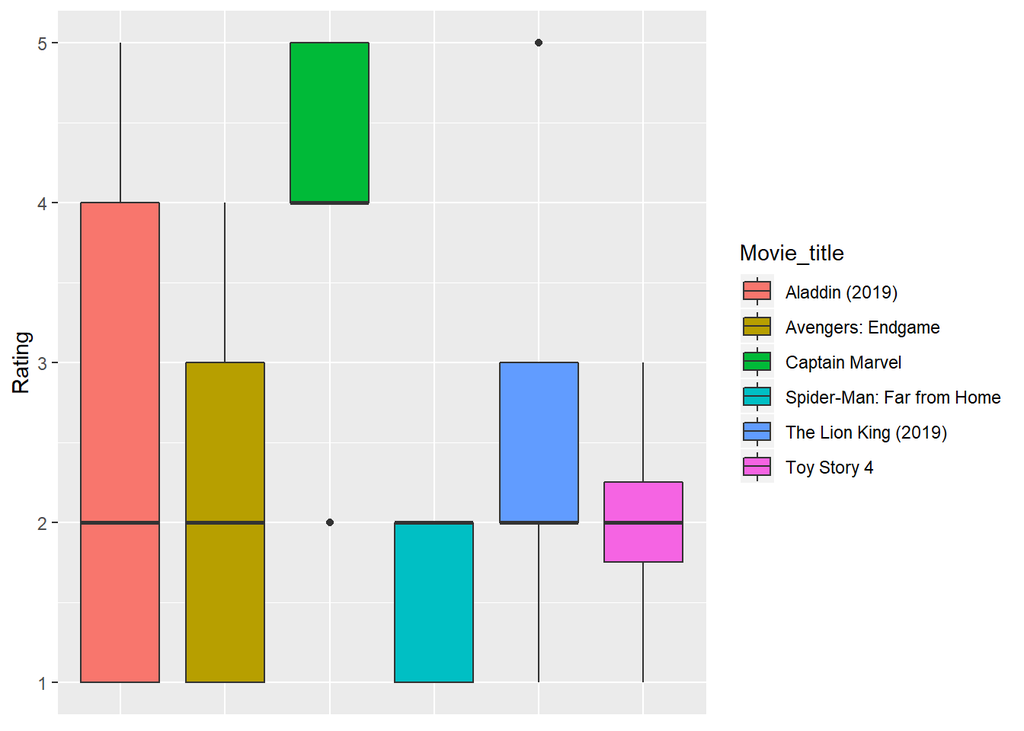

```r
ggplot(result, aes(x=Movie_title, y=Rating, fill=Movie_title)) +
  geom_boxplot() +
  theme(axis.title.x=element_blank(),
        axis.text.x=element_blank(),
        axis.ticks.x=element_blank())
```

###### We can see that Captain Marvel was quite popular, with mean and median ratings of 4:

```r
result[result$Movie_title=="Captain Marvel",]
```

```
##       Movie_title Friend_name Rating
## 11 Captain Marvel      Andrew      4
## 12 Captain Marvel     Bernard      5
## 13 Captain Marvel     Charlie      5
## 14 Captain Marvel     Dilbert      2
## 15 Captain Marvel     Ernesto      4
```

###### while Spider-Man: Far from Home was at the opposite end of the spectrum, receiving the lowest ratings:

```r
result[result$Movie_title=="Spider-Man: Far from Home",]
```

```
##                  Movie_title Friend_name Rating
## 16 Spider-Man: Far from Home      Andrew      2
## 17 Spider-Man: Far from Home     Bernard      1
## 18 Spider-Man: Far from Home     Charlie      1
## 19 Spider-Man: Far from Home     Dilbert      2
## 20 Spider-Man: Far from Home     Ernesto      2
```

### Now, Let’s look at how each **friend** tended to rate the films:

```r
describeBy(result$Rating,group = result$Friend_name )
```

```
##
##  Descriptive statistics by group
## group: Andrew
##    vars n mean   sd median trimmed  mad min max range  skew kurtosis   se
## X1    1 6 2.67 1.21    2.5    2.67 1.48   1   4     3 -0.04    -1.88 0.49
## ------------------------------------------------------------------------------------------
## group: Bernard
##    vars n mean   sd median trimmed  mad min max range skew kurtosis   se
## X1    1 6  2.5 1.97    1.5     2.5 0.74   1   5     4 0.45    -1.98 0.81
## ------------------------------------------------------------------------------------------
## group: Charlie
##    vars n mean   sd median trimmed  mad min max range skew kurtosis   se
## X1    1 6 2.33 1.51      2    2.33 1.48   1   5     4 0.71    -1.15 0.61
## ------------------------------------------------------------------------------------------
## group: Dilbert
##    vars n mean   sd median trimmed mad min max range skew kurtosis   se
## X1    1 6 2.33 1.37      2    2.33   0   1   5     4 1.07    -0.43 0.56
## ------------------------------------------------------------------------------------------
## group: Ernesto
##    vars n mean  sd median trimmed  mad min max range  skew kurtosis   se
## X1    1 5  2.8 1.3      3     2.8 1.48   1   4     3 -0.26    -1.96 0.58
```

##### Again, we have to exclude the item with the NA:

```r
result[!is.na(result$Rating),] %>%
  group_by(Friend_name) %>%
  summarize(count=n(),
            min=min(Rating),
            mean=mean(Rating),
            median=median(Rating),
            max=max(Rating),
            sd=sd(Rating),
            IQR=IQR(Rating)
            )
```

```
## # A tibble: 5 x 8
##   Friend_name count   min  mean median   max    sd   IQR
##   <chr>       <int> <int> <dbl>  <dbl> <int> <dbl> <dbl>
## 1 Andrew          6     1  2.67    2.5     4  1.21  1.75
## 2 Bernard         6     1  2.5     1.5     5  1.97  3.25
## 3 Charlie         6     1  2.33    2       5  1.51  1.5
## 4 Dilbert         6     1  2.33    2       5  1.37  0
## 5 Ernesto         5     1  2.8     3       4  1.30  2
```

##### Boxplot by friend:

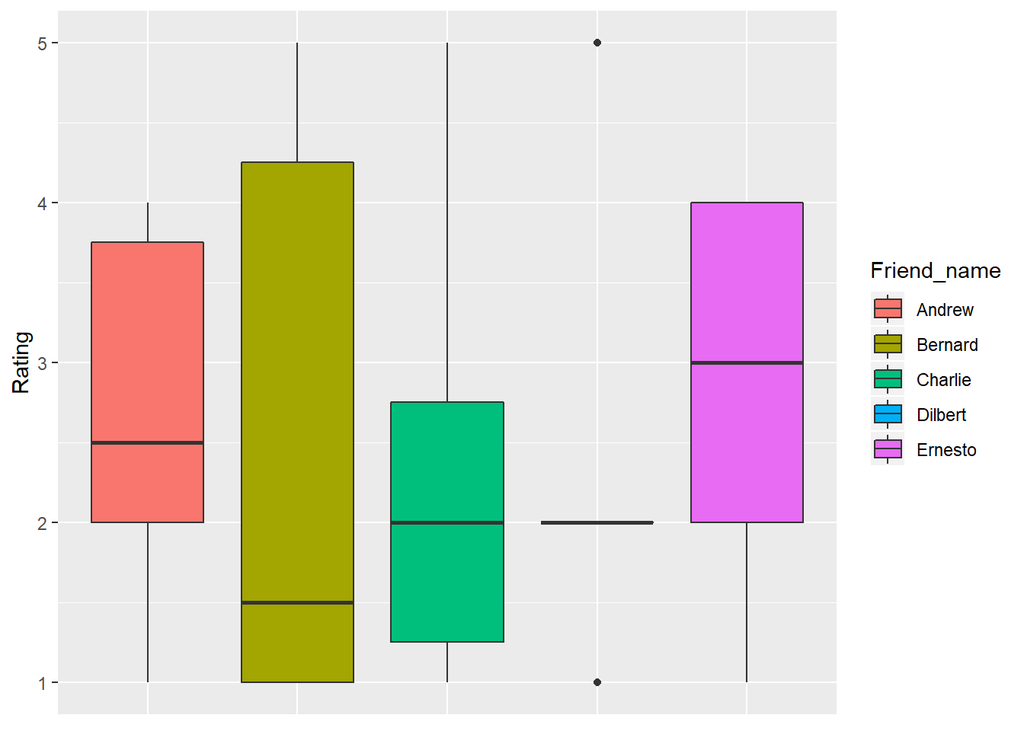

```r
ggplot(result, aes(x=Friend_name, y=Rating, fill=Friend_name)) +
  geom_boxplot() +
  theme(axis.title.x=element_blank(),
        axis.text.x=element_blank(),
        axis.ticks.x=element_blank())
```

###### We observe that Bernard either likes a film or hates it – with Bernard, there is no middle ground.

###### Bernard gave the widest disperion among his ratings, using mostly “1”s and “5”s, which explains his large IQR and standard deviation.

###### His Median is the lowest, as half his ratings were “1”s:

```r
result[result$Friend_name=="Bernard",]
```

```
##                  Movie_title Friend_name Rating
## 2             Aladdin (2019)     Bernard      5
## 7          Avengers: Endgame     Bernard      1
## 12            Captain Marvel     Bernard      5
## 17 Spider-Man: Far from Home     Bernard      1
## 22      The Lion King (2019)     Bernard      1
## 27               Toy Story 4     Bernard      2
```

###### Because Dilbert gave so many ratings of “2”, his IQR = 0, thus his box is flat, with outliers at “1” and “5” :

```r
result[result$Friend_name=="Dilbert",]
```

```
##                  Movie_title Friend_name Rating
## 4             Aladdin (2019)     Dilbert      2
## 9          Avengers: Endgame     Dilbert      2
## 14            Captain Marvel     Dilbert      2
## 19 Spider-Man: Far from Home     Dilbert      2
## 24      The Lion King (2019)     Dilbert      5
## 29               Toy Story 4     Dilbert      1
```

### Conclusion:

With a small data set (6 movies and 5 reviewers) the aggregated figures display interesting results across both movie and reviewer.

It would be interesting to see the results across a larger sample, for example using the data assembled by “Rotton Tomatoes” which tabulates published movie reviews and scores films on a scale of 0%-100% based upon the percentage of reviews which are favorable vs. unfavorable.

Furthermore, it would be interesting to compare/contrast such “professional” assessments with opinions from individuals, such as those assembled by firms like Amazon.